# Introduction to stringr

Putting strings together with stringr For your first stringr function, we’ll look at str_c(), the c is short for concatentate, a function that works like paste(). It takes vectors of strings as input along with sep and collapse arguments.

There are two key ways str_c() differs from paste(). First, the default separator is an empty string, sep = “”, as opposed to a space, so it’s more like paste0(). This is an example of a stringr function, performing a similar operation to a base function, but using a default that is more likely to be what you want. Remember in your pizza order, you had to set sep = “” multiple times.

The second way str_c() differs to paste() is in its handling of missing values. paste() turns missing values into the string “NA”, whereas str_c() propagates missing values. That means combining any strings with a missing value will result in another missing value.

Let’s explore this difference using your pizza order from the previous chapter.

```r
library(stringr)
my_toppings <- c("cheese", NA, NA)
my_toppings_and <- paste(c("", "", "and "), my_toppings, sep = "")
# Print my_toppings_and
my_toppings_and
```

```
[1] "cheese" "NA"     "and NA"
```

```r
# Use str_c() instead of paste(): my_toppings_str
my_toppings_str <- str_c(c("","","and "), my_toppings, sep = "")
# Print my_toppings_str
my_toppings_str
```

```
[1] "cheese" NA       NA
```

```r
# paste() my_toppings_and with collapse = ", "
paste(my_toppings_and, collapse = ", ")
```

```
[1] "cheese, NA, and NA"
```

```r
# str_c() my_toppings_str with collapse = ", "
str_c(my_toppings_str, collapse = ", ")
```

```
[1] NA
```

String length Our next stringr function is str_length(). str_length() takes a vector of strings as input and returns the number of characters in each string. For example, try finding the number of characters in Batman’s name:

str_length(c(“Bruce”, “Wayne”)) This is very similar to the base function nchar() but you’ll see in the exercises str_length() handles factors in an intuitive way, whereas nchar() will just return an error.

Historically, nchar() was even worse, rather than returning an error if you passed it a factor, it would return the number of characters in the numeric encoding of the factor. Thankfully this behavior has been fixed, but it was one of the original motivations behind str_length().

Take your first look at babynames by asking if girls’ names are longer than boys’ names.

```r
library(babynames)
library(dplyr)
# Extracting vectors for boys' and girls' names
babynames_2014 <- filter(babynames, year == 2014)
boy_names <- filter(babynames_2014, sex == "M")$name
girl_names <- filter(babynames_2014, sex == "F")$name
# Take a look at a few boy_names
head(boy_names)
```

```
[1] "Noah"    "Liam"    "Mason"   "Jacob"   "William" "Ethan"
```

```r
# Find the length of all boy_names
boy_length <- str_length(boy_names)
# Take a look at a few lengths
head(boy_length)
```

```
[1] 4 4 5 5 7 5
```

```r
# Find the length of all girl_names
girl_length <- str_length(girl_names)
# Find the difference in mean length
mean(girl_length) - mean(boy_length)
```

```
[1] 0.3360496
```

```r
# Confirm str_length() works with factors
head(str_length(factor(boy_names)))
```

```
[1] 4 4 5 5 7 5
```

Extracting substrings The str_sub() function in stringr extracts parts of strings based on their location. As with all stringr functions, the first argument, string, is a vector of strings. The arguments start and end specify the boundaries of the piece to extract in characters.

For example, str_sub(x, 1, 4) asks for the substring starting at the first character, up to the fourth character, or in other words the first four characters. Try it with my Batman’s name:

str_sub(c(“Bruce”, “Wayne”), 1, 4) Both start and end can be negative integers, in which case, they count from the end of the string. For example, str_sub(x, -4, -1), asks for the substring starting at the fourth character from the end, up to the first character from the end, i.e. the last four characters. Again, try it with Batman:

str_sub(c(“Bruce”, “Wayne”), -4, -1) To practice, you’ll use str_sub() to look at popular first and last letters for names.

```r
# Extract first letter from boy_names
boy_first_letter <- str_sub(boy_names,1,1)
# Tabulate occurrences of boy_first_letter
table(boy_first_letter)
```

```
boy_first_letter
   A    B    C    D    E    F    G    H    I    J    K    L    M    N    O    P    Q    R
1450  651  767  996  549  185  332  401  234 1388 1290  536  913  424  207  230   56  778
   S    T    U    V    W    X    Y    Z
 804  771   43  160  174   56  252  379
```

```r
# Extract the last letter in boy_names, then tabulate
boy_last_letter <- str_sub(boy_names, -1, -1)
table(boy_last_letter)
```

```
boy_last_letter
   a    b    c    d    e    f    g    h    i    j    k    l    m    n    o    p    q    r
 421  104   92  436 1145   66   81  582  704   57  349  942  389 4664  729   32   19 1011
   s    t    u    v    w    x    y    z
 825  291   81   71   34   86  696  119
```

```r
# Extract the first letter in girl_names, then tabulate
girl_first_letter <- str_sub(girl_names, 1,1)
table(girl_first_letter)
```

```
girl_first_letter
   A    B    C    D    E    F    G    H    I    J    K    L    M    N    O    P    Q    R
3099  698  941  808  932  209  345  468  373 1429 1689 1121 1744  752  143  301   38  830
   S    T    U    V    W    X    Y    Z
1366  681   28  214   85   62  294  500
```

```r
# Extract the last letter in girl_names, then tabulate
girl_last_letter <- str_sub(girl_names, -1, -1)
table(girl_last_letter)
```

```
girl_last_letter
   a    b    c    d    e    f    g    h    i    j    k    l    m    n    o    p    q    r
6624   20   13   81 3111    8   21 1936 1580   12   31  450  115 2600  104    3    2  291
   s    t    u    v    w    x    y    z
 326  208   59    6   17   49 1432   51
```

Detecting matches str_detect() is used to answer the question: Does the string contain the pattern? It returns a logical vector of the same length as that of the input vector string, with TRUE for elements that contain the pattern and FALSE otherwise.

Let’s take a look at a simple example where you have a vector of strings that represent pizza orders:

pizzas <- c(“cheese”, “pepperoni”, “sausage and green peppers”) You can ask which orders contain the pattern “pepper”, with

str_detect(pizzas, pattern = fixed(“pepper”)) Try it out! You should get FALSE TRUE TRUE. Notice how both pepperoni and green peppers contain the pattern of interest.

The output from str_detect() can be used to count the number of occurrences, or to subset out the strings that contain the pattern. You’ll practice both to find the boys’ names that contain “zz”.

```r
# Look for pattern "zz" in boy_names
contains_zz <- str_detect(string = boy_names, pattern = "zz")
# Examine str() of contains_zz
str(contains_zz)
```

```
 logi [1:14026] FALSE FALSE FALSE FALSE FALSE FALSE ...
```

```r
# How many names contain "zz"?
sum(contains_zz)
```

```
[1] 16
```

```r
# Which names contain "zz"?
boy_names[contains_zz]
```

```
 [1] "Uzziah"    "Ozzie"     "Ozzy"      "Uzziel"    "Jazz"      "Chazz"     "Izzy"
 [8] "Azzam"     "Izzac"     "Izzak"     "Fabrizzio" "Jazziel"   "Azzan"     "Izzaiah"
[15] "Muizz"     "Yazziel"
```

```r
boy_df <- filter(babynames, year < 2014 & year > 2009)
# Which rows in boy_df have names that contain "zz"?
boy_df[contains_zz,]
```

| year | sex | name | n | prop |
| --- | --- | --- | --- | --- |
| 2010 | F | Tahlia | 95 | 4.854734e-05 |
| 2010 | F | Maira | 89 | 4.548119e-05 |
| 2010 | F | Cori | 82 | 4.190402e-05 |
| 2010 | F | Kemya | 31 | 1.584176e-05 |
| 2010 | F | Brecken | 30 | 1.533074e-05 |
| 2010 | F | Danisha | 26 | 1.328664e-05 |
| 2010 | F | Palin | 25 | 1.277561e-05 |
| 2010 | F | Bryley | 22 | 1.124254e-05 |
| 2010 | F | Bryar | 20 | 1.022049e-05 |
| 2010 | F | Nikolette | 13 | 6.643320e-06 |

[output cut: 143 more lines]

Subsetting strings based on match Since detecting strings with a pattern and then subsetting out those strings is such a common operation, stringr provides a function str_subset() that does that in one step.

For example, let’s repeat our search for “pepper” in our pizzas using str_subset():

pizzas <- c(“cheese”, “pepperoni”, “sausage and green peppers”) str_subset(pizzas, pattern = fixed(“pepper”)) We get a new vector of strings, but it only contains those original strings that contained the pattern.

str_subset() can be easily confused with str_extract(). str_extract() returns a vector of the same length as that of the input vector, but with only the parts of the strings that matched the pattern. This won’t be very interesting until we know about regular expressions, so we’ll talk more about this in Chapter 3.

For now, you’ll repeat part of the last exercise using str_subset() and then find a few other interesting names.

```r
# Find boy_names that contain "zz"
str_subset(boy_names, "zz")
```

```
 [1] "Uzziah"    "Ozzie"     "Ozzy"      "Uzziel"    "Jazz"      "Chazz"     "Izzy"
 [8] "Azzam"     "Izzac"     "Izzak"     "Fabrizzio" "Jazziel"   "Azzan"     "Izzaiah"
[15] "Muizz"     "Yazziel"
```

```r
# Find girl_names that contain "zz"
str_subset(girl_names, "zz")
```

```
 [1] "Izzabella"  "Jazzlyn"    "Jazzlynn"   "Lizzie"     "Izzy"       "Lizzy"
 [7] "Mazzy"      "Izzabelle"  "Jazzmine"   "Jazzmyn"    "Jazzelle"   "Jazzmin"
[13] "Izzah"      "Jazzalyn"   "Jazzmyne"   "Izzabell"   "Jazz"       "Mazzie"
[19] "Alyzza"     "Izza"       "Izzie"      "Jazzlene"   "Lizzeth"    "Jazzalynn"
[25] "Jazzy"      "Alizzon"    "Elizzabeth" "Jazzilyn"   "Jazzlynne"  "Jizzelle"
[31] "Izzabel"    "Izzabellah" "Izzibella"  "Jazzabella" "Jazzabelle" "Jazzel"
[37] "Jazzie"     "Jazzlin"    "Jazzlyne"   "Aizza"      "Brizza"     "Ezzah"
[43] "Fizza"      "Izzybella"  "Rozzlyn"
```

```r
# Find girl_names that contain "U"
starts_U <- str_subset(girl_names, "U")
starts_U
```

```
 [1] "Unique"  "Uma"     "Unknown" "Una"     "Uriah"   "Ursula"  "Unity"   "Umaiza"
 [9] "Urvi"    "Ulyana"  "Ula"     "Udy"     "Urwa"    "Ulani"   "Umaima"  "Umme"
[17] "Ugochi"  "Ulyssa"  "Umika"   "Uriyah"  "Ubah"    "Umaira"  "Umi"     "Ume"
[25] "Urenna"  "Uriel"   "Urijah"  "Uyen"
```

```r
# Find girl_names that contain "U" and "z"
str_subset(starts_U, "z")
```

```
[1] "Umaiza"
```

Counting matches Another stringr function that takes a vector of strings and a pattern is str_count(). str_count() answers the question “How many times does the pattern occur in each string?”. It always returns an integer vector of the same length as that of the input vector.

If you count the occurrences of “pepper” in your pizzas, you’ll find no occurrences in the first, and one each in the second and third,

pizzas <- c(“cheese”, “pepperoni”, “sausage and green peppers”) str_count(pizzas, pattern = fixed(“pepper”)) Perhaps a little more interesing is to count how many “e”s occur in each order

str_count(pizzas, pattern = fixed(“e”)) You’ll use str_count() to find some names with lots of repeated letters.

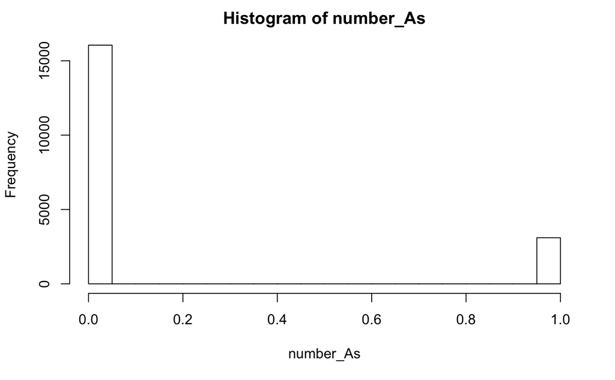

```r
# Count occurrences of "a" in girl_names
number_as <- str_count(girl_names, pattern = fixed("a"))
# Count occurrences of "A" in girl_names
number_As <- str_count(girl_names, pattern = fixed("A"))
# Histograms of number_as and number_As
hist(number_As)
```

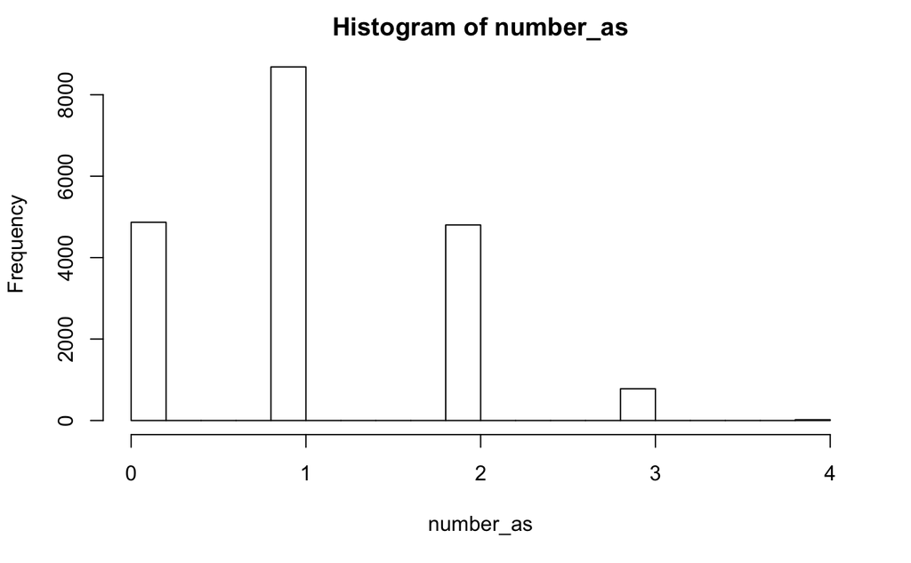

```r
hist(number_as)
```

```r
# Find total "a" + "A"
total_as <- number_as + number_As
# girl_names with more than 4 a's
girl_names[total_as>4]
```

```
[1] "Aaradhana"
```

Parsing strings into variables A common use for str_split() is to pull apart raw string data into more useful variables. In this exercise you’ll start by pulling apart a date range, something like “23.01.2017 - 29.01.2017”, into separate variables for the start of the range, “23.01.2017”, and the end of the range, “29.01.2017”.